# Evaluating Homelessness as an Independent risk factor for Hepatitis A

Aman Sahani

Data Visualization

Mat no - 12201412

email - aman.sahani@stud.th-deg.de

# Problem Definition

Evaluating Homelessness as an Independent risk factor for Hepatitis A. Through this project I want to analyze the spread of hepatitis A along different states of the United States of America throughout the years and simultaneously evaluate homelessness as an independent risk factor.

# Overview

Hepatitis A is a vaccine-preventable liver infection caused by the hepatitis A virus (HAV). HAV is found in the stool and blood of people who are infected. Hepatitis A is very contagious. It is spread when someone unknowingly ingests the virus — even in microscopic amounts — through close personal contact with an infected person or through eating contaminated food or drink.

Symptoms of hepatitis A can last up to 2 months and include fatigue, nausea, stomach pain, and jaundice.

Transmission / Exposure The hepatitis A virus is found in the stool and blood of people who are infected:

- Person-to-person contact
- Eating contaminated food or drink

Since Hepatitis is closely related to Sanitation I am trying to find the correlation between Hepatitis A spread and Homelessness. The higher homelessness proportion usually leads to low sanitation and increased drug abuse both can then easily spread hepatitis.

# Methods

We first Start the analysis by loading the tycho dataset for Hepatitis A and performing and Exploratory Data Analysis on the subject.

Installing Packages

```r
library(dplyr)
library(tidyverse)
```

```r
library(highcharter)
library(data.table)
library(ggplot2)
library(hrbrthemes)
library(corrplot)
library(usmap)
library(hrbrthemes)
library(viridis)
library(cowplot)
#library(plyr)
libs <- c("dplyr", "ggplot2", "plotly", "reshape2", "magrittr", "ggthemes", "tidyr", "DT", "lubridate", "stringr", "RColorBrewer", "knitr", "highcharter")
lapply(libs, require, character.only = TRUE)
```

[output not shown]

```r
add.libs <- c("rgeos","rgdal", "raster", "viridis", "gtable", "grid", "haven", "viridisLite")
lapply(add.libs, require, character.only = TRUE)
```

[output not shown]

Loading Tycho Acute Hepatitis A dataset and having a brief look at the heading of the table

```r
tychodf = read.csv("usa hepatitis a.csv")
```

Performing EDA on the dataset.

1. Looking at the head of the dataset

```r
head(tychodf)
```

```
##                  ConditionName ConditionSNOMED            PathogenName
## 1 Acute type A viral hepatitis        25102003 Human hepatitis A virus
## 2 Acute type A viral hepatitis        25102003 Human hepatitis A virus
## 3 Acute type A viral hepatitis        25102003 Human hepatitis A virus
## 4 Acute type A viral hepatitis        25102003 Human hepatitis A virus
## 5 Acute type A viral hepatitis        25102003 Human hepatitis A virus
## 6 Acute type A viral hepatitis        25102003 Human hepatitis A virus
##   PathogenTaxonID Fatalities              CountryName CountryISO Admin1Name
## 1          208726          0 UNITED STATES OF AMERICA         US  WISCONSIN
## 2          208726          0 UNITED STATES OF AMERICA         US  WISCONSIN
## 3          208726          0 UNITED STATES OF AMERICA         US       OHIO
## 4          208726          0 UNITED STATES OF AMERICA         US       OHIO
## 5          208726          0 UNITED STATES OF AMERICA         US       OHIO
## 6          208726          0 UNITED STATES OF AMERICA         US       OHIO
##   Admin1ISO Admin2Name CityName PeriodStartDate PeriodEndDate
```

[output cut: 27 more lines]

compactly displaying the internal structure of the dataset for closer analysis

```r
str(tychodf)
```

```
## 'data.frame':    41058 obs. of  20 variables:
##  $ ConditionName              : chr  "Acute type A viral hepatitis" "Acute type A viral hepatitis" "Acute type A viral hepatitis" "Acute type A viral hepatitis" ...
##  $ ConditionSNOMED            : int  25102003 25102003 25102003 25102003 25102003 25102003 25102003 25102003 25102003 25102003 ...
##  $ PathogenName               : chr  "Human hepatitis A virus" "Human hepatitis A virus" "Human hepatitis A virus" "Human hepatitis A virus" ...
##  $ PathogenTaxonID            : int  208726 208726 208726 208726 208726 208726 208726 208726 208726 208726 ...
##  $ Fatalities                 : int  0 0 0 0 0 0 0 0 0 0 ...
##  $ CountryName                : chr  "UNITED STATES OF AMERICA" "UNITED STATES OF AMERICA" "UNITED STATES OF AMERICA" "UNITED STATES OF AMERICA" ...
##  $ CountryISO                 : chr  "US" "US" "US" "US" ...
##  $ Admin1Name                 : chr  "WISCONSIN" "WISCONSIN" "OHIO" "OHIO" ...
##  $ Admin1ISO                  : chr  "US-WI" "US-WI" "US-OH" "US-OH" ...
##  $ Admin2Name                 : logi  NA NA NA NA NA NA ...
##  $ CityName                   : logi  NA NA NA NA NA NA ...
##  $ PeriodStartDate            : chr  "2010-01-03" "2013-09-15" "2006-01-29" "2006-02-12" ...
##  $ PeriodEndDate              : chr  "2010-01-09" "2013-09-21" "2006-02-04" "2006-02-18" ...
##  $ PartOfCumulativeCountSeries: int  0 0 0 0 0 0 0 0 0 0 ...
##  $ AgeRange                   : chr  "0-130" "0-130" "0-130" "0-130" ...
##  $ Subpopulation              : chr  "None specified" "None specified" "None specified" "None specified" ...
##  $ PlaceOfAcquisition         : logi  NA NA NA NA NA NA ...
##  $ DiagnosisCertainty         : logi  NA NA NA NA NA NA ...
##  $ SourceName                 : chr  "US Nationally Notifiable Disease Surveillance System" "US Nationally Notifiable Disease Surveillance System" "US Nationally Notifiable Disease Surveillance System" "US Nationally Notifiable Disease Surveillance System" ...
##  $ CountValue                 : int  1 1 2 3 1 4 4 1 4 2 ...
```

This gives a an accurate information of the number of rows and columns present including the values and their format. We can decide the columns to keep and what columns we need to transform.

Based on the above Information - Removing the cols not required and fixing time to years

```r
year <- format(as.Date(tychodf$PeriodEndDate, format="%Y-%m-%d"),"%Y")
tychodf$Year <- year
tychodf <- tychodf %>%
  select(ConditionName,Fatalities,Admin1Name,Year,CountValue)
```

Get a sum of CountValue i.e. the number of recorded Hepatitis A Cases.

```r
summary(tychodf$CountValue)
```

```
##    Min. 1st Qu.  Median    Mean 3rd Qu.    Max.
##    0.00    2.00    7.00   26.79   23.00 1411.00
```

This give a little more information about the minimum and max value of the hepatitis A cases reported. The Median is being 7 and Mean is 26.79 for all years for all states.

Five num sum

```r
fivenum(tychodf$CountValue)
```

```
## [1]    0    2    7   23 1411
```

The five number sum tells us about the following minimum value, lower-hinge value, median value, upper-hinge value and maximum value

First lets analyse the rise and fall of the hepatitis A cases by aggregating it according to year for each region. Also removed a few states which had incomplete data Group by Year and create a heatmap to understand the rise/fall through time

```r
hepaAyearsAgg <- setNames( aggregate(tychodf$CountValue,by=list(tychodf$Admin1Name,tychodf$Year), FUN=sum), c("State","Year","Cases"))
usastatearea <- setNames(data.frame(cbind(state.name,state.region , state.area)),c("State","Region","Area in sqmi"))
usastatearea$State %<>% tolower()
hepaAyearsAgg$State %<>% tolower()
usaalldata <- merge(hepaAyearsAgg,usastatearea, by="State",all.x = TRUE)
usaalldata$`Area in sqmi` <- as.integer(as.character(usaalldata$`Area in sqmi`))
usaalldata <- subset(usaalldata, State!="wyoming" & State!="guam" & State!="new york" & State!="district of columbia" & State!="minnesota" & State!="south dakota" & State !="puerto rico")
head(usaalldata)
```

```
##     State Year Cases Region Area in sqmi
## 1 alabama 2010   233      2        51609
## 2 alabama 2017   367      2        51609
## 3 alabama 2013   191      2        51609
## 4 alabama 2006   340      2        51609
## 5 alabama 2015   601      2        51609
## 6 alabama 2011   120      2        51609
```

Heatmap

```r
tempdf <- usaalldata
tempdf <- filter(usaalldata,Year >=2007 & Year<=2016)
tempdf %<>% group_by(Region,Year) %>% summarise(`Average No of Cases` = mean(Cases))
```

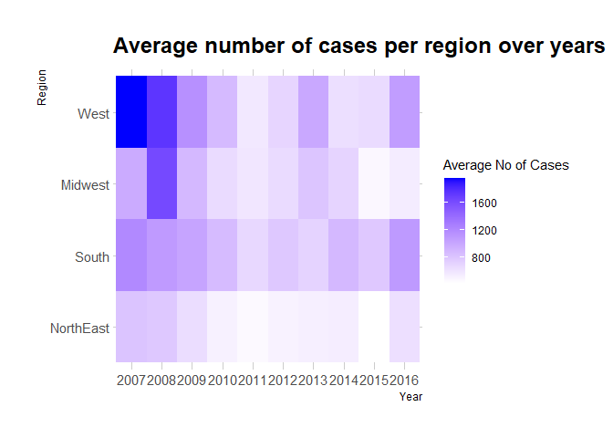

```r
ylabels <- c("NorthEast","South","Midwest","West")

p <- ggplot(tempdf,aes(Year, Region, fill=`Average No of Cases`)) + geom_tile()+  scale_fill_gradient(low="white", high="blue") +
  theme_ipsum() + scale_y_discrete(labels = ylabels) + ggtitle("Average number of cases per region over years")
options(warn=-1)
p
```

Plotting a usa map to visualize the mean number of cases across years according to each state.

[figure not shown]

```r
temp1 <- usaalldata
#temp %<>% filter(Year == 2015)
temp1 %<>% group_by(State) %>% summarise(mean = mean(Cases))
#temp
temp1 <- temp1 %>% arrange(desc(mean))
temp1$mean <- temp1$mean
usastatearea <- setNames(data.frame(cbind(state.name,state.abb)),c("State","state"))
usastatearea$State %<>% tolower()
temp1 <- merge(temp1,usastatearea, by="State",all.x = TRUE)
plot_usmap(data = temp1, values = "mean", color = "red",labels = TRUE) +
  scale_fill_continuous(low = "white", high = "blue",name = "Mean", label = scales::comma) +
  theme(legend.position = "right", plot.title = element_text(color = "black", size = 12, face = "bold",hjust = 0.5)) + ggtitle("USA States with Mean of Hepatits A cases from 2007 to 2016")
```

We get a gist of states who have been relatively on the higher side for the number of Hepatitis A cases aggregated over the years.

In order to calculate Correlation let’s load all the homelessness and population dataset.

Lets load homelessness and population dataset of 2007 to 2016

```r
dfhomeless = read.csv("2007-2016-Homelessnewss-USA.csv")
year <- format(as.Date(dfhomeless$Year, format="%d/%m/%Y"),"%Y")
dfhomeless$Year <- year
dfhomeless$Count <- as.integer(as.character(dfhomeless$Count))
dfhomeless[is.na(dfhomeless)] <- 0
dfhomeless <- dfhomeless %>%
  select(State,Measures,Year,Count)
#head(dfhomeless)

#Renaming state code to actual State Name
old_names <- c("AK","CA","DC","GA","ID","KY","ME","MS","ND","NJ","OH","PR","SD","VA","WI","AL","CO","DE","HI","IL","LA","MI","MT","NE","NM","OK","RI","TN","VT","WV","AR","CT","FL","IA","IN","MA","MN","NC","NH","NV","OR","SC","TX","WA","WY","AZ","KS","MD","MO","NY","PA","UT","GU")

new_names <- c("Alaska","California","District of Columbia","Georgia","Idaho","Kentucky","Maine","Mississippi","North Dakota","New Jersey","Ohio","Puerto Rico","South Dakota","Virginia","Wisconsin","Alabama","Colorado","Delaware","Hawaii","Illinois","Louisiana","Michigan","Montana","Nebraska","New Mexico","Oklahoma","Rhode Island","Tennessee","Vermont","West Virginia","Arkansas","Connecticut","Florida","Iowa","Indiana","Massachusetts","Minnesota","North Carolina","New Hampshire","Nevada","Oregon","South Carolina","Texas","Washington","Wyoming","Arizona","Kansas","Maryland","Missouri","New York","Pennsylvania","Utah","Guam")

naming_key <- setNames(object = old_names, nm = new_names)

dfhomeless <- dfhomeless %>%
    mutate(State = factor(State, levels = old_names,
              labels = new_names))
#head(dfhomeless)
dfhomeless <- dfhomeless[complete.cases(dfhomeless),]
dfhomeless <- setNames( aggregate(dfhomeless$Count,by=list(dfhomeless$State,dfhomeless$Year), FUN=sum), c("State","Year","HomelessCount"))

#dfhomeless %<>% group_by(State,Year) %>% summarise(mean = mean(Count))
#dfhomeless[4597,]
#new_DF <- dfhomeless[rowSums(is.na(dfhomeless)) > 0,]
#new_DF
dfhomeless$State %<>% toupper()
head(dfhomeless)
```

```
##                  State Year HomelessCount
## 1               ALASKA 2007          7124
## 2           CALIFORNIA 2007        103077
## 3 DISTRICT OF COLUMBIA 2007          1001
## 4              GEORGIA 2007         14872
## 5                IDAHO 2007          6018
## 6             KENTUCKY 2007          7265
```

Loading Population Dataset

```r
popall2010_19 <- read.csv("nst-est2019-alldata.csv")
popall2010_19 <- setNames(popall2010_19[, c("NAME","POPESTIMATE2010","POPESTIMATE2011","POPESTIMATE2012","POPESTIMATE2013","POPESTIMATE2014","POPESTIMATE2015","POPESTIMATE2016")],c("NAME","2010","2011","2012","2013","2014","2015","2016"))
popalldf2000_10 <- read.csv("st-est00int-01.csv")
popalldf2000_10 <- setNames(popalldf2000_10[,c("Geographic.Area","X2001","X2002","X2003","X2004","X2005","X2006","X2007","X2008","X2009")],c("NAME","2001","2002","2003","2004","2005","2006","2007","2008","2009"))

popAllYrsdf <- merge(popalldf2000_10,popall2010_19, by="NAME")
nm1 <- c("2001","2002","2003","2004","2005","2006","2007","2008","2009")
popAllYrsdf[nm1] <- lapply(popAllYrsdf[nm1], gsub, pattern = ",", replacement = "")
cols.num <- c("2001","2002","2003","2004","2005","2006","2007","2008","2009")
popAllYrsdf[cols.num] <- sapply(popAllYrsdf[cols.num], as.integer)
#sapply(popAllYrsdf, class)
#popAllYrsdf

pop2007_2016df <- popAllYrsdf[,c("NAME","2007","2008","2009","2010","2011","2012","2013","2014","2015","2016")]

pop2007_2016df <- setNames(cbind(pop2007_2016df[1], stack(pop2007_2016df[2:11])),c("State", "PopulationCount","Year"))
pop2007_2016df <- pop2007_2016df[,c(1,3,2)]
pop2007_2016df$State %<>% toupper()

pop2007_2016df$State %<>% tolower()
#tychodf
popWithHepaAcases <- setNames( aggregate(tychodf$CountValue,by=list(tychodf$Admin1Name,tychodf$Year), FUN=sum), c("State","Year","Hepatitis A cases"))
popWithHepaAcases <- subset(popWithHepaAcases, Year >=2007 & Year <= 2016)
popWithHepaAcases$State %<>% tolower()

tempdf <- right_join(pop2007_2016df,popWithHepaAcases, by=c("State"="State","Year"="Year"))
dfhomeless$State %<>% tolower()
alldatadf <- right_join(tempdf,dfhomeless, by=c("State"="State","Year"="Year"))

alldatadf$CasesPer10000 <- (alldatadf$`Hepatitis A cases`/alldatadf$PopulationCount)*10000
alldatadf$HomelessnessPer10000 <- (alldatadf$HomelessCount /alldatadf$PopulationCount)*10000
#alldatadf
usastatearea <- setNames(data.frame(cbind(state.name,state.region , state.area)),c("State","Region","Area in sqmi"))
usastatearea$State %<>% tolower()
combineddf <- merge(alldatadf,usastatearea, by="State",all.x = TRUE)
combineddf$`Area in sqmi` <- as.integer(as.character(combineddf$`Area in sqmi`))
combineddf <- subset(combineddf, State!="wyoming" & State!="guam" & State!="new york" & State!="district of columbia" & State!="minnesota" & State!="south dakota" & State !="puerto rico" & State!="north dakota")
combineddf$Density <- combineddf$PopulationCount/combineddf$`Area in sqmi`
head(combineddf)
```

```
##     State Year PopulationCount Hepatitis A cases HomelessCount CasesPer10000
## 1 alabama 2012         4815588               462         21826     0.9593844
## 2 alabama 2007         4672840               436         18921     0.9330514
## 3 alabama 2010         4785437               233         20079     0.4868939
## 4 alabama 2015         4852347               601         19185     1.2385759
## 5 alabama 2009         4757938               268         19472     0.5632692
## 6 alabama 2011         4799069               120         23587     0.2500485
##   HomelessnessPer10000 Region Area in sqmi  Density
## 1             45.32364      2        51609 93.30907
## 2             40.49144      2        51609 90.54312
## 3             41.95855      2        51609 92.72485
## 4             39.53757      2        51609 94.02133
## 5             40.92529      2        51609 92.19202
## 6             49.14912      2        51609 92.98899
```

To identify the correlation between various factors we will use the correlation matrix. Corellation matrix

```r
temp1 <- combineddf
#temp %<>% filter(Year == 2015)
temp1 %<>% select(`Hepatitis A cases`,PopulationCount,HomelessCount,CasesPer10000,HomelessnessPer10000,Density)
res <- cor(temp1, use="pairwise.complete.obs")
round(res, 2)
```

```
##                      Hepatitis A cases PopulationCount HomelessCount
## Hepatitis A cases                 1.00            0.81          0.66
## PopulationCount                   0.81            1.00          0.86
## HomelessCount                     0.66            0.86          1.00
## CasesPer10000                     0.34            0.02          0.01
## HomelessnessPer10000             -0.19           -0.27          0.03
## Density                           0.10            0.13          0.21
##                      CasesPer10000 HomelessnessPer10000 Density
## Hepatitis A cases             0.34                -0.19    0.10
## PopulationCount               0.02                -0.27    0.13
## HomelessCount                 0.01                 0.03    0.21
## CasesPer10000                 1.00                 0.11    0.04
## HomelessnessPer10000          0.11                 1.00   -0.03
## Density                       0.04                -0.03    1.00
```

From the table we can identify various correlations but we will plot a correation graph in order to easily visualize correlations

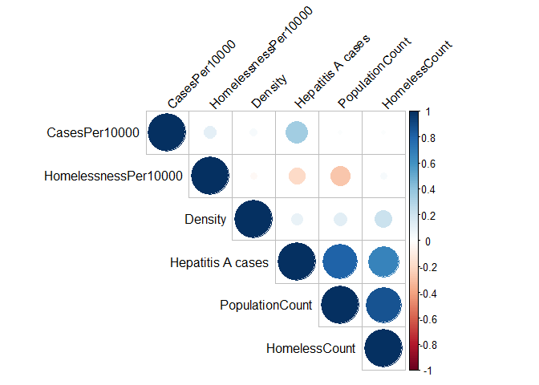

```r
corrplot(res, type = "upper", order = "hclust",
         tl.col = "black", tl.srt = 45)
```

In order to view the relation between Homelessness and Hepatitis A cases I will plot a bar graph including mean number of cases for each state aggregated throughout the years.

```r
temp <- combineddf
#temp %<>% filter(Year == 2015)
temp %<>% group_by(State) %>% summarise(mean = mean(`Hepatitis A cases`), meanHomeless = mean(HomelessCount))
#temp
temp <- temp %>% arrange(desc(mean))



bar1 <- (highchart() %>%
           hc_title(text ="Hepatitis A and Homelessness Mean Comparison",align="center") %>%
           hc_xAxis(categories = temp$State, title = list(text="State")) %>%
           hc_yAxis(title = list(text="Number of Cases")) %>%
           hc_add_series(name = "Mean Number of Hepatitis Cases", data= temp$mean, stack = "Cases") %>%
           hc_add_series(name = "Mean Number of Homeless", data = temp$meanHomeless/10, stack = "Homeless") %>%
           hc_chart(type = "column",
           options3d = list(enabled = TRUE, beta = 15, alpha = 15)) %>%
           #hc_add_series(temp,"line",hcaes(x=temp$State,y=temp$meanHomeless)) %>%
           hc_add_theme(hc_theme_538())
)
bar1
```

[interactive chart not shown]

From the above graph it looks like the states having higher homelessness population have higher Hepatitis A cases such as California, Florida, Arizona and states having lower homelessness population have lower hepatitis A cases such as Vermont, Delware etc.

```r
temp <- combineddf
temp %<>% filter(Year == 2016)
temp %<>% group_by(State) %>% summarise(mean = mean(CasesPer10000), meanHomeless = mean(HomelessnessPer10000))
#temp
temp <- temp %>% arrange(desc(mean))


bar1 <- (highchart() %>%
           hc_title(text ="Hepatitis A and Homelessness per Population Comparison ",align="center") %>%
           hc_xAxis(categories = temp$State, title = list(text="State")) %>%
           hc_yAxis(title = list(text="Number of Cases per 10000")) %>%
           hc_add_series(name = "Mean Number of Hepatitis Cases per 10000", data= temp$mean, stack = "Cases") %>%
           hc_add_series(name = "Mean Number of Homeless per 1000", data = temp$meanHomeless/10, stack = "Homeless") %>%
           hc_chart(type = "column",
           options3d = list(enabled = TRUE, beta = 15, alpha = 15)) %>%
           #hc_add_series(temp,"line",hcaes(x=temp$State,y=temp$meanHomeless)) %>%
           hc_add_theme(hc_theme_538())
)
bar1
```

[interactive chart not shown]

The same results are now inconclusive Alaska which were at the last in previous graph having low homelessness and low hepatitis A cases are now above having higher number of homelessness but having low number of hepatitis A cases.

Hawaii can be considered as an Outlier and still there are many states with higher number of homelessness but having low number of hepatitis A cases.

We will no take 4 states and try to calculate the relation between hepatitis A cases, Homelessness and Density over the years keeping population as a factor.

Two states with Highest mean number of Hepatitis A cases

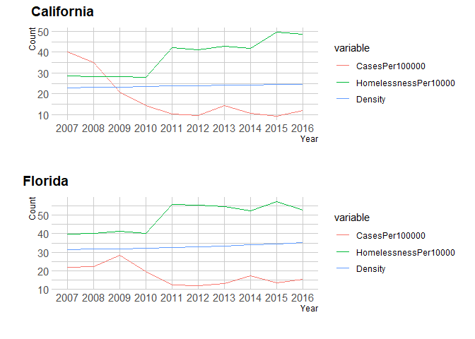

```r
temp4charts <- combineddf
#temp4charts %<>% filter(State=='california')
temp4charts <- temp4charts %>% select(State,Year,CasesPer10000,HomelessnessPer10000,Density)
temp4charts <- setNames(temp4charts,c("State","Year","CasesPer100000","HomelessnessPer10000","Density"))
temp4charts$Density <- temp4charts$Density/10
temp4charts$CasesPer100000 <- temp4charts$CasesPer100000*10
tempcachart <- temp4charts %<>% filter(State=='california')
#tempflchart
df <- melt(tempcachart%>% select(Year,CasesPer100000,HomelessnessPer10000,Density), id.vars='Year')
#df
ca <- df %>%
  ggplot( aes(x=Year, y=value, group=variable, color=variable)) +geom_line() +
    theme_ipsum() +
    ylab("Count")

temp4charts <- combineddf
#temp4charts %<>% filter(State=='california')
temp4charts <- temp4charts %>% select(State,Year,CasesPer10000,HomelessnessPer10000,Density)
temp4charts <- setNames(temp4charts,c("State","Year","CasesPer100000","HomelessnessPer10000","Density"))
temp4charts$Density <- temp4charts$Density/10
temp4charts$CasesPer100000 <- temp4charts$CasesPer100000*10
tempflchart <- temp4charts %<>% filter(State=='florida')
#tempflchart
df <- melt(tempflchart%>% select(Year,CasesPer100000,HomelessnessPer10000,Density), id.vars='Year')
#df
fl <- df %>%
  ggplot( aes(x=Year, y=value, group=variable, color=variable)) +geom_line()  + theme_ipsum_rc() +
    ylab("Count")
options(warn=-1)

plot_grid(ca, fl, labels=c("California", "Florida"), ncol = 1, nrow = 2)
```

Two states having higher number of homelessness but lower number of Hepatitis A cases.

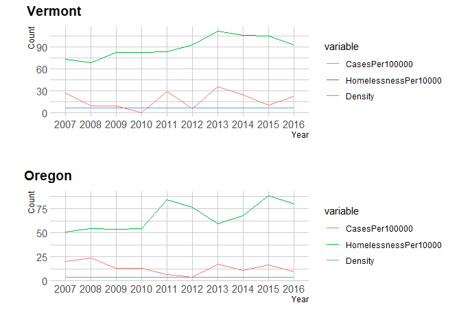

```r
temp4charts <- combineddf
#temp4charts %<>% filter(State=='california')
temp4charts <- temp4charts %>% select(State,Year,CasesPer10000,HomelessnessPer10000,Density)
temp4charts <- setNames(temp4charts,c("State","Year","CasesPer100000","HomelessnessPer10000","Density"))
temp4charts$Density <- temp4charts$Density/10
temp4charts$CasesPer100000 <- temp4charts$CasesPer100000*10
tempcachart <- temp4charts %<>% filter(State=='vermont')
#tempflchart
df <- melt(tempcachart%>% select(Year,CasesPer100000,HomelessnessPer10000,Density), id.vars='Year')
#df
ca <- df %>%
  ggplot( aes(x=Year, y=value, group=variable, color=variable)) +geom_line() +
    theme_ipsum() +
    ylab("Count")

temp4charts <- combineddf
#temp4charts %<>% filter(State=='california')
temp4charts <- temp4charts %>% select(State,Year,CasesPer10000,HomelessnessPer10000,Density)
temp4charts <- setNames(temp4charts,c("State","Year","CasesPer100000","HomelessnessPer10000","Density"))
temp4charts$Density <- temp4charts$Density/10
temp4charts$CasesPer100000 <- temp4charts$CasesPer100000*10
tempflchart <- temp4charts %<>% filter(State=='oregon')
#tempflchart
df <- melt(tempflchart%>% select(Year,CasesPer100000,HomelessnessPer10000,Density), id.vars='Year')
#df
fl <- df %>%
  ggplot( aes(x=Year, y=value, group=variable, color=variable)) +geom_line() +
    theme_ipsum() +
    ylab("Count")
options(warn=-1)
plot_grid(ca, fl, labels=c('Vermont', 'Oregon'), ncol = 1, nrow = 2)
```

From the above 4 graphs the rise and fall of homelessness is not directly proportional to the rise and fall of Hepatitis A cases.

Even thought there is slight correlation between Homelessness and Hepatitis A it is mostly attributed to the population Count. After taking the population as a variable we found out that there is no direct correlation between these two.

# Result

Although there seems to be a huge correlation between the number of hepatitis A cases and homelessness however most of that correlation does not apply once we take population into account.